# ECON 709: Reproducible Research Projects

author: Brad R. Humphreys date: Spring 2022 autosize: true

# What is Reproducible Research?

- “Reproducibility is just collaboration with people you don’t know, including yourself next week” quote from Philip Stark, University of California Berkeley Statistics Department
- Designing a research project so that an independent outside observer can reproduce all results in your final paper without any instructions from you, using your code and data
- Building blocks of reproducible research:
1. file, folder, and variable naming
2. folder structure
3. metadata
4. raw data integrity
5. scripting

# Why Undertake Reproducible Research?

- Journals are increasingly requiring submission of code and data along with papers, also employing data editors to check replication
- Facilitates collaborative research
- Helps your future self. This approach will save you hundreds, perhaps thousands of hours spent “reinventing the wheel” over your career
- Trust me on this. I learned the hard way.
- Also useful in disseminating your research. Example: this presentation is available on my Github repository

https://github.com/brhumphreys/reproducible_research_presentation

# Naming Conventions

- All names should provide information about the contents
- Names should be “human readable”
- Never, never, never include spaces in any folder or file name
- No “garbage” characters! @#$~&*+= and the like
- Use “-” and “_” for readability
- Take advantage of standard OS ordering: 0-9, a-z (and left pad initial numbers)
- Bad: datafile 1.csv
- Good: raw_price_data_from_bls.csv

# Folder Structure

- Folder names convey information about folder contents
- Needs to be adaptable to your project
- I often use something along these lines

📁 project_name  
|── README.md  
|── requirements.txt  
|── code/  
|── data/  
|── literature/  
|── documents/  
|── workflow/

# Metadata

- Data on data. The who, what, when, where, why, how of your research.
- Every folder should have a file with metadata for that folder
- Every file that analyzes data should have metadata at the top in comments
- Many formats out there, I prefer README.md files using basic markdown
- More information:
- README.md metadata https://data.research.cornell.edu/content/readme
- General https://data.research.cornell.edu/content/writing-metadata

========================================================  
📁 project  
|── README.md  
|── requirements.txt  
|── raw_data/  
| ├── bls_raw_price_data.csv  
| └── README.md  
|── code/  
| ├── 01_utilities.R  
| ├── 02_data_cleaning.R  
| ├── 03_analysis.R  
| └── 04_generate_plots_and_tables.R  
| └── README.md  
|── results/  
| ├── cleaned_data.csv  
| └── derived_data.csv  
| └── README.md  
***

|── outputs/  
| └── latex/  
| ├── README.md  
| ├── paper.tex  
| └── slides.tex  
| ── floats/  
| ├── README.md  
| ├── table.tex  
| └── time_series_plot.pdf

# Raw Data Integrity

- Key component of reproducible research
- You will collect data from somewhere (scraping, downloading. etc.)
- Put this in the raw_data/ folder and treat it as read only!
- Never, never, never make changes to these files “by hand” in a text editor or spreadsheet
- Why? Because those changes are not documented, so the independent observer cannot reproduce then
- All data manipulation should be scripted

# Script Everything

- Never, never, never enter command line code
- Even if you are just “exploring” a data set, use a script
- Script names should reflect contents
- Include metadata in comments at the top iof every script. When it was writtemn, what id does what input files it needs, what it produces
- Use comments in your scripts. This is for the future you. Trust me, they are important
- Ideally have one “master” script that runs all scripts needed to read, clean, mainpulate and analyze data

========================================================  
**Folder 1**  
01_read-raw-price-data.R  
02_merge-in-state-data.R  
03_deflate-to-2020-dollars.R  
04_make-time-series-graph.R  
05_summary-stat-table.R  
06_results-table-ols.R  
07_results-table-iv.R  
08_make-scatter-plot.R  
09_robustness-check-cluster.R  
10_run-all-files.R  
***

**Folder 2**  
deflateit.R  
first&secondstaiv.R  
makegraphsts.R  
othresult21.R  
read 11.R  
runolsmodel.R  
scttrpl1.R  
st dt mg.R  
sumst1125.R

# Example: Humphreys, J Sports Econ 2000

- Old paper of mine, but I still have my project folder

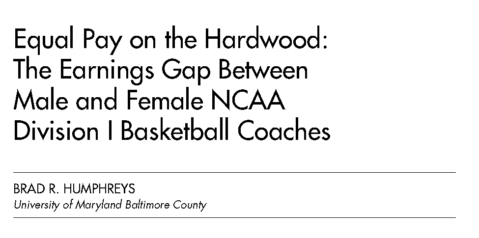

- Lets see how this project folder organization holds up

========================================================

[figure not shown]

- The folder structure is OK, but what’s “auto” and “backup”?
- No idea, but I have to open the folder to see. That’s bad
- First question: where’s the paper?
- Ugh, it’s in the main jse2000/ project folder

========================================================

[figure not shown]

- That’s a mess. No idea where the final document is
- And what’s all that other stuff?
- No metadata, of course. That would be helpful
- Needs a documents/ folder and subfolder structure

========================================================

[figure not shown]

***

- More poor naming, and a mish-mash of file formats
- SAS data files. Doubt I could open them now.
- This highlights the importance of saving raw data files in a portable format like text

========================================================

[figure not shown]

***

- Lets take a look at the code
- SAS scripts, of course. At least they are text files!
- Poor naming convention, can’t tell what is going on
- No STATA .do files. I wonder how the STATA data files in data/ were created?

========================================================

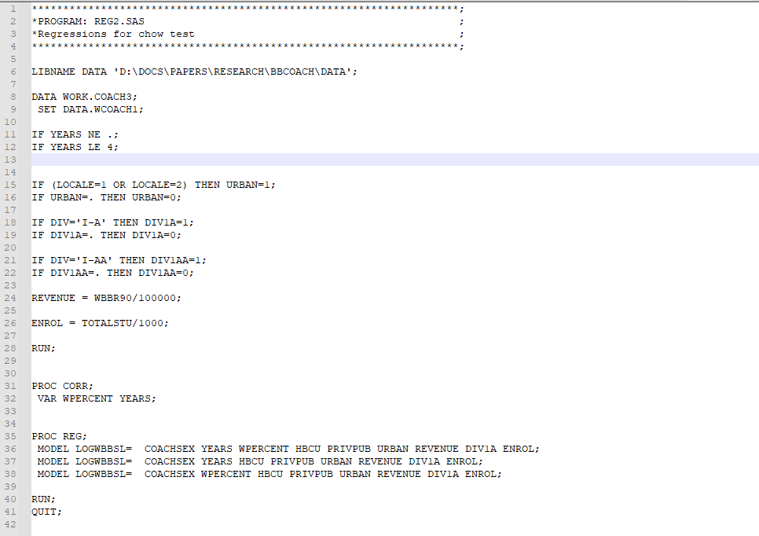

***

- Here’s a script
- Sketchy metadata at top, no comments :-(

# Final Assessment of my Former Self

- Did 2000 Brad leave 2022 Brad enough information to understand the project? LOL Noope!
- Folder structure C+
- File naming C-
- Folder metadata F
- Code metadata C+
- Reproducible? Not a chance